# School Electricity Analysis

George Pavloglou

September 2018

*(View the [README](https://github.com/gpavloglou/SchoolElectricity/blob/gh-pages/README.md) for background information on this project)*

# Scoping Population of Study

1. Schools for which electricity data was aggregated for the 2017-18 business plan
   1. Schools with electricity data for period between Apr 2016 and March 2017
   2. Including only schools that were open for all 12 months
   3. only include schools for which enrolments were known during period
   4. Must include floor area (floor area must not equal 0 or be missing)
   5. Include school type (e.g. ‘Primary’, ‘Secondary’, ‘Special’, etc)
2. Indicate whether on xxxxxx Electricity Program. If on xxxx Electricity Program, then must be indicated as having had sensors installed for at least 12 months (**already confirmed in creation of dataset**).
3. Indicate whether schools were confirmed to have used solar during period (**already confirmed in creation of dataset**). Note: schools indicated as having solar were confirmed as having used solar at least once during period based on whether there was a feed-in tariff payment identified in their billing.
4. Indicate if they were xxxxxx Schools. But they must have been on this program for all 12 months (**already confirmed in creation of dataset**).

# Import, Inspect and Clean Data

## Import Data

```r
# Set Working Directory
setwd("F:\\GeorgesFile\\R\\SchoolElectricity_VSBA_201803")

# Activate Packages
pckgs <- c("tidyverse","readxl","broom", "janitor", "oilabs","car", "caret", "gridExtra","grid","cowplot","PerformanceAnalytics","plotly","lmtest","sandwich", "het.test", "ggthemes", "jtools", "MASS", "estimatr")
sapply(pckgs, require, character.only = TRUE)

# Import Dataset
Elec201617 <- read_excel("SchoolElectricity201617v5.xlsx", na = c("","#N/A","NA"))

# Convert into Dataframe
Elec201617 <- as.data.frame(Elec201617)

# Inspect Data
# glimpse(Elec201617)
# View(Elec201617)
# summary(Elec201617)
```

## Clean Data (Round 1)

### Review missing data

```r
# Review missing data
Elec201617[!complete.cases(Elec201617),]
```

11 rows with missing data. Many of the schools with missing data are those where ‘Match with Enrol?’ == ‘N’. If these are excluded, then fewer missing data to deal with. Exclude rows where Match with Enrol is “N”.

```r
# Exclude rows where Match with Enrol is "N".
Elec201617 <- Elec201617 %>%
  filter(Enrol != "N")

# Inspect missing data again:
Elec201617[!complete.cases(Elec201617),]

# Since Geography for xxxxxxx School is known this can be filled in manually:
Elec201617[492,"Geography"] <- "Regional Centre"

# Re-check remaining missing data:
Elec201617[!complete.cases(Elec201617),]
```

### Check for any *numeric* values that are zero

```r
# Subset only numeric columns
Search0 <- Elec201617[,sapply(Elec201617,is.numeric)]

# Return rows where column value = 0
for(i in 1:ncol(Search0)){
  print(names(Search0[i]))
  print(which(Search0[,i]==0))
}
```

```
## [1] "Activity Quantity\r\n(kWh p.a.)"
## integer(0)
## [1] "Area"
## integer(0)
## [1] "Avg. kWh p.a. per m2\r\n(kWh/m2)"
## integer(0)
## [1] "Est_Annual_Cost"
## integer(0)
## [1] "Est_Avg_$_per_kWh"
## integer(0)
## [1] "QtyMonthsOpenInPeriod"
## integer(0)
## [1] "WeightedAvBuildingAge\r\n(by original construction date)"
## integer(0)
## [1] "Enrol"
## integer(0)
## [1] "kWhPerEnrol"
## integer(0)
```

```r
rm(Search0)
```

No zero values found for any numeric variables.

### Filter out unwanted values based on Population Definition

```r
Elec201617 %>%
  filter(QtyMonthsOpenInPeriod != 12) # New schools that opened at start of 2017. Filter these out.
Elec201617 <- Elec201617 %>%
  filter(QtyMonthsOpenInPeriod == 12)


# Weighted Av Building Age < 12 investigation

# Rename Column Name:
Elec201617 <- rename(Elec201617,
                     BuildAge = `WeightedAvBuildingAge\r\n(by original construction date)`)

# Now investigate for BuildAge < 12
Elec201617 %>% filter(BuildAge < 12)
```

**Explanation for BuildAge < 12:** A weighted average age of buildings (by original construction date) less than 12 must mean that some recent capital works have taken place in those 79 schools within the past year. The school where BuildAge = x officially opened in xxx 20xx and had first school term in xxx 20xx. This is therefore also a new school, which may have had more capital works or refurbishments between Apr 20xx and Mar 20xx. Keep BuildAge as is for now.

```r
# Re-check data for further filtering:
#glimpse(Elec201617)
#summary(Elec201617)

# Check Match with Enrol
Elec201617 %>% filter(`Match with Enrol?` == "Y") # Returns 1,458 rows
nrow(Elec201617) # 1,458 rows
levels(Elec201617$`Match with Enrol?`) # No more 'Match with Enrol' == "N"
```

Confirmed that all criteria against ‘Match with Enrol’ variable met (as per previous filter). Now start removing variables unnecessary for analysis.

### Remove Variables not needed for analysis

- Remove `Match with Enrol?`
- Remove QtyMonthsOpenInPeriod (all values = 12, therefore redundant)

```r
Elec201617 <- Elec201617 %>%
  dplyr::select(., -c(`Match with Enrol?`, QtyMonthsOpenInPeriod))
```

### Rename Variables

```r
Elec201617 <- rename(
    Elec201617,Elec = `Activity Quantity\r\n(kWh p.a.)`,
    kWh_m2 = `Avg. kWh p.a. per m2\r\n(kWh/m2)`,
    Cost = Est_Annual_Cost,
  Cost_kWh = `Est_Avg_$_per_kWh`,
  Type = School_Type,
  kWh_Enrol = kWhPerEnrol)

# glimpse(Elec201617)
```

### Transform Variables

- Change specific variables into factor
- Include additional cost variables
- Round values of specific variables to two decimal places

#### Change specific variables into **factors:**

- Type
- SWEP
- Solar
- Geography
- NatHERS
- RSS
- BCAZone

```r
# Change specific variables into factors:
Elec201617$Type <- as.factor(Elec201617$Type) # Type
Elec201617$SWEP <- as.factor(Elec201617$SWEP)   #SWEP
Elec201617$Solar <- as.factor(Elec201617$Solar) #Solar
Elec201617$Geography <- as.factor(Elec201617$Geography)  #Geography
Elec201617$NatHERS <- as.factor(Elec201617$NatHERS) #NatHERS
Elec201617$RSS <- as.factor(Elec201617$RSS) #RSS
Elec201617$BCA <- as.factor(Elec201617$BCA) #BCA
#str(Elec201617)

# 1) Rename and check levels:
   # Rename level "Pri/Sec" into "PriSec"
       levels(Elec201617$Type)[levels(Elec201617$Type) == "Pri/Sec"] <- "PriSec"

   # Rename level "Regional Centre" into "Regional"
       levels(Elec201617$Geography)[levels(Elec201617$Geography) == "Regional Centre"] <-"Regional"

    # Re-check levels for $Type, $Geography, $BCA
        lapply(Elec201617[c("Type","Geography", "BCA")],levels) # changes confirmed
```

```
## $Type
## [1] "Language"  "PriSec"    "Primary"   "Secondary" "Special"
##
## $Geography
## [1] "Regional" "Rural"    "Urban"
##
## $BCA
## [1] "Zone_4" "Zone_6" "Zone_7"
```

```r
# 2) Choose Reference Level in Factor Variables:
# Let 'Primary' be the reference level for the factor 'Type'
# Let 'Urban' be the reference level for the factor 'Geography'
# Let 'Zone_6' be the reference level for the factor 'BCA'


Elec201617$Type <- factor(Elec201617$Type,
                          levels = c("Primary", "Secondary", "PriSec", "Special","Language"))

Elec201617$Geography <- factor(Elec201617$Geography,
                               levels = c("Urban", "Regional", "Rural"))

Elec201617$BCA <- factor(Elec201617$BCA,
                         levels = c("Zone_6", "Zone_4","Zone_7"))

# levels(Elec201617$Type)  change confirmed
# levels(Elec201617$Geography)  change confirmed
# levels(Elec201617$BCA) change confirmed

# Check whether factors are ordered:
# sapply(Elec201617[,c("Type","SWEP","Solar","Geography","NatHERS","RSS","BCA")],is.ordered)
```

#### Include additional cost variables

```r
Elec201617 <-  Elec201617 %>%
  mutate(Cost_m2 = Cost/Area,
         Cost_Enrol = Cost/Enrol)
```

#### Round ‘double’ type variables two decimal places

If the variable is of type “double”, then use the following function: round(.,2) (i.e. round all data to two decimal places)

```r
Elec201617 <- Elec201617 %>%
  mutate_if(is.double, funs(round(.,2)))
```

### Change from data frame to a tibble

```r
tbl1617 <- as.tbl(Elec201617)
```

Now ready to commence exploratory data analysis.

## Exploratory Data Analysis (Round 1)

```r
# summary(tbl1617)
```

**Outstanding Observations:**

- Only xx Language Schools existed in the entire school portfolio over the period, and these are captured here.
- Two (2) NAs for BuildAge
- Only 5 per cent (n = xxx) in this sample are on the SWEP electricity program
- About 35 per cent (n = xxx) were identified as having used solar
- Only 5 per cent (n = xxx) were in NaTHERS zones 20 or 27
- Lowest kWh per sqm is 0.38 kWh per m<sup>2</sup>

### Plots and Summary Stats

#### Summary Plot: Electricity Consumption

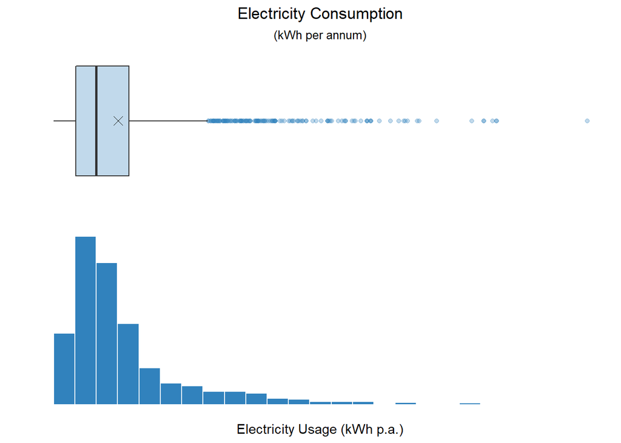

```r
# Boxplot:
boxplotP <- ggplot(data = tbl1617, aes(x = "", y = Elec)) +
  geom_boxplot(alpha = 0.3, fill = "#3182bd", outlier.colour = "#3182bd") +
  stat_summary(fun.y = mean,
               geom = "point",
               shape = 4,
               size = 3) +
  ggtitle("Electricity Consumption",
          subtitle = "(kWh per annum)") +
  scale_y_continuous(breaks = seq(0,1200000, 300000)) +
  xlab("") +
  ylab("") +
  coord_flip() +
  theme_minimal() +
  theme(plot.title = element_text(hjust = 0.5),
        plot.subtitle = element_text(hjust = 0.5),
        legend.position = 0)  +
  # remove if showing plot publically
  theme(axis.text = element_blank(),
        panel.grid = element_blank())


# Histogram:
histP <- ggplot(data = tbl1617, aes(x = Elec)) +
  geom_histogram( fill = "#3182bd", binwidth = 50000, colour = "white") +
  scale_x_continuous(breaks = seq(0,1200000, 300000)) +
  xlab("Electricity Usage (kWh p.a.)") +
  ylab("") +
  theme_minimal() +
  theme(plot.title = element_text(hjust = 0.5),
        plot.subtitle = element_text(hjust = 0.5),
        legend.position = 0) +
  # remove figures if showing plot publicly
  theme(axis.text = element_blank(),
        panel.grid = element_blank())

# Produce combined boxplot/histogram plot:
grid.arrange(boxplotP, histP, ncol = 1)
```

### Summary Statistics (Sample Electricity and Cost)

```r
(Elec_SummaryStats <- sapply(tbl1617[,c("Elec","Cost")], summary))
```

### Summary Statistics: by School Type

#### Summary Tables

```r
# Summary Stats: Electricity by School Type
 by(tbl1617$Elec, tbl1617$Type, summary)

# Total Electricity by School Type
 tbl1617 %>%
   dplyr::select(Elec, Type) %>%
   group_by(Type) %>%
   summarise(Total = sum(Elec),
                        Percent = round(Total/sum(tbl1617$Elec),3))
```

#### Summary Plot

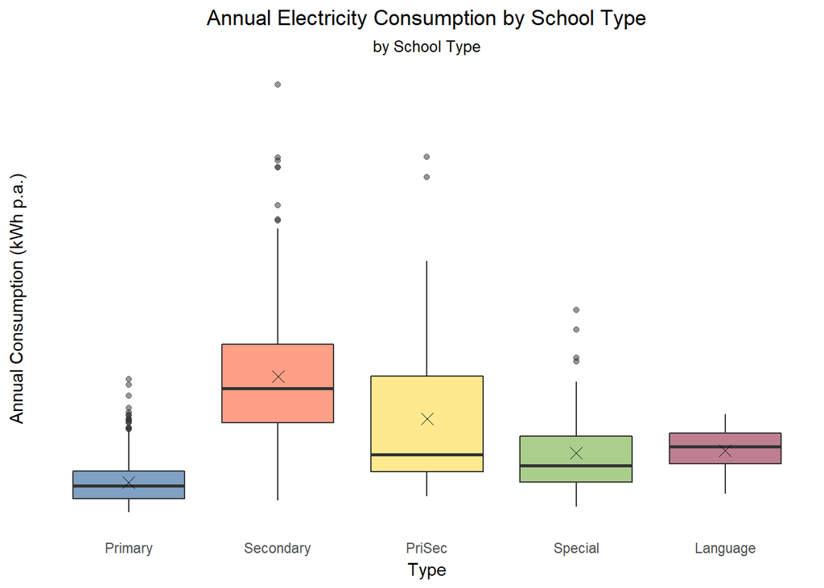

```r
### Box Plots: Electricity consumption by School Type
ggplot(data = tbl1617, aes(x = Type, y = Elec, fill = Type)) +
  geom_boxplot(alpha = 0.5) +
  stat_summary(fun.y = mean,
               geom = "point",
               shape = 4,
               size = 3) +
  ggtitle("Annual Electricity Consumption by School Type",
          subtitle = "by School Type") +
  ylab("Annual Consumption (kWh p.a.)")+
  theme_minimal() +
  scale_fill_calc() +
  theme(plot.title = element_text(hjust = 0.5),
        plot.subtitle = element_text(hjust = 0.5),
        legend.position = 0) +
  # remove figures if showing plot publicly
  theme(axis.text.y = element_blank(),
        panel.grid = element_blank())
```

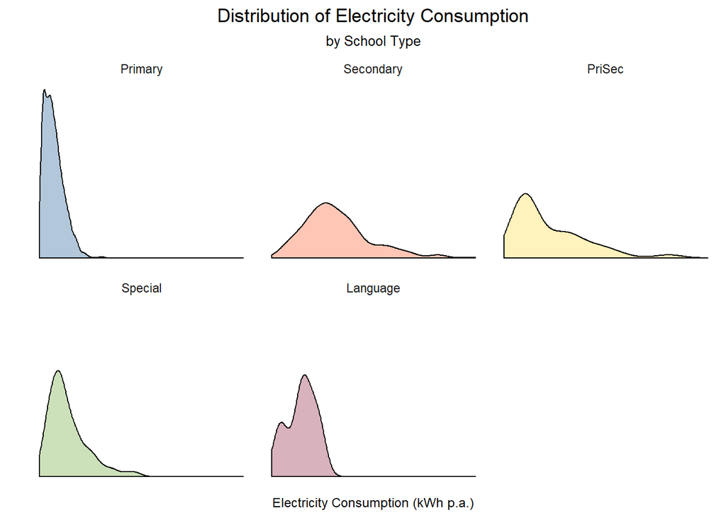

```r
### Density Plot: Electricity consumption by School Type
ggplot(data = tbl1617, aes(x = Elec, fill = Type)) +
  geom_density(alpha = 0.3) +
  ggtitle("Distribution of Electricity Consumption",
          "by School Type") +
  xlab("Electricity Consumption (kWh p.a.)") +
  ylab("")+
  facet_wrap(~Type) +
  scale_fill_calc()+
  theme_minimal() +
  theme(plot.title = element_text(hjust = 0.5),
        plot.subtitle = element_text(hjust =0.5),
        axis.title = element_text(size = 9),
        legend.position = 0)+
  # remove figures if showing plot publicly
  theme(axis.text = element_blank(),
        panel.grid = element_blank())
```

### Explore Electricity per Floor area

```r
 tbl1617 %>%
   dplyr::select(kWh_m2, Type) %>%
   group_by(Type) %>%
   summarise(Mean = mean(kWh_m2),
             StDev = round(sd(kWh_m2),3),
             MAD = mad(kWh_m2, constant = 1)) %>%
   arrange(desc(Mean))
```

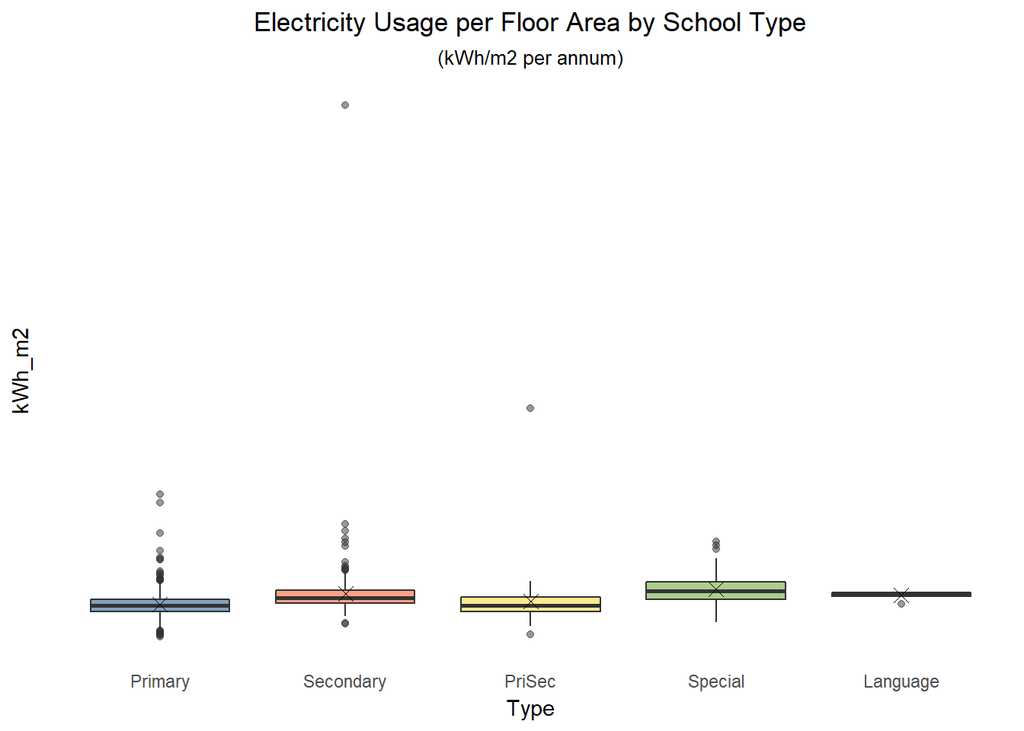

```r
### Box Plots: Electricity per Floor Area consumption by School Type
ggplot(data = tbl1617, aes(x = Type, y = kWh_m2, fill = Type)) +
  geom_boxplot(alpha = 0.5) +
  stat_summary(fun.y = mean,
               geom = "point",
               shape = 4,
               size = 3) +
  ggtitle("Electricity Usage per Floor Area by School Type",
          subtitle = "(kWh/m2 per annum)") +
  scale_fill_calc() +
  theme_minimal() +
  theme(plot.title = element_text(hjust = 0.5),
        plot.subtitle = element_text(hjust = 0.5),
        legend.position = 0) +
  # remove figures if showing plot publicly
  theme(axis.text.y  = element_blank(),
        panel.grid = element_blank())
```

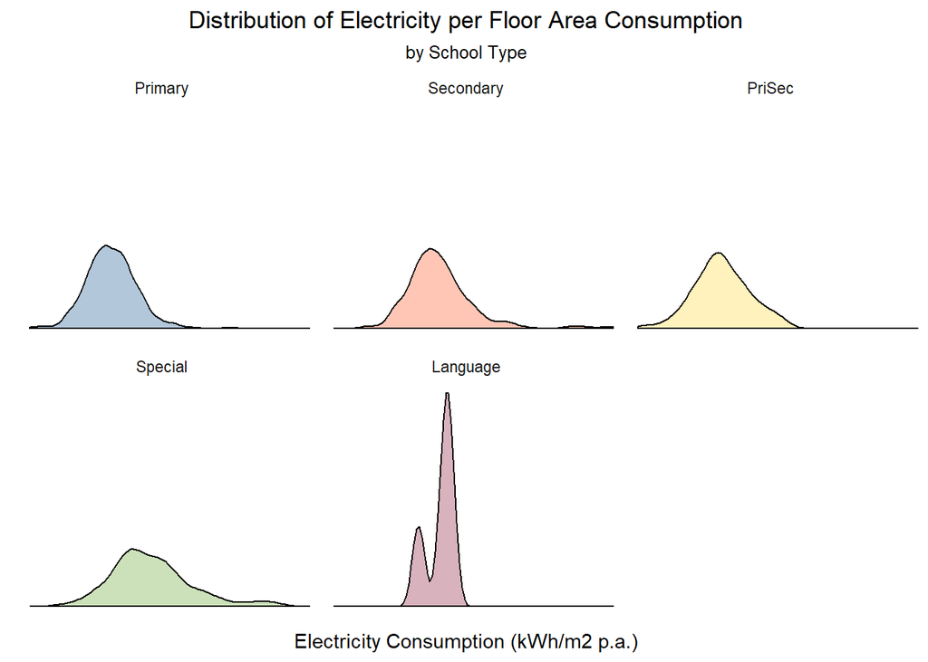

```r
### Density Plot: Electricity consumption per Floor Area by School Type
ggplot(data = tbl1617, aes(x = kWh_m2, fill = Type)) +
  geom_density(alpha = 0.3) +
  ggtitle("Distribution of Electricity per Floor Area Consumption",
          "by School Type") +
  xlab("Electricity Consumption (kWh/m2 p.a.)") +
  facet_wrap(~Type) +
  coord_cartesian(xlim = c(0,75)) +
  scale_fill_calc() +
  theme_minimal() +
  theme(plot.title = element_text(hjust = 0.5),
        plot.subtitle = element_text(hjust =0.5),
        axis.title.y = element_blank(),
        legend.position = 0) +
  # remove figures if showing plot publicly
  theme(axis.text = element_blank(),
        panel.grid = element_blank())
```

## Explore kWh/m<sup>2</sup> Outliers

```r
# Top 5 kWh/m2 outliers by School Type

 tbl1617  %>%
   dplyr::select(1,5,3:4,8) %>%
   arrange(desc(kWh_m2)) %>%
   arrange(Type) %>%
   group_by(Type) %>%
   top_n(5,kWh_m2)

tbl1617[1216,1:5]  #Unusually small floor Area


# Bottom 5 kWh/m2 outliers by School Type

 tbl1617  %>%
   dplyr::select(1,5,3:4,8) %>%
   arrange(kWh_m2) %>%
   arrange(Type) %>%
   group_by(Type) %>%
   top_n(-5,kWh_m2)
```

**N.B:** Extensive inspection of kWh/m2 outliers performed; involved examination, and where necessary, removal and/or update of observations.

## Clean Data (Round 2)

### Remove spurious observations

```r
remove <- -c(233,  346,  796, 1049, 1137, 1216)
tbl1617 <- tbl1617[remove,]
```

### Review Electricity per Enrolment Data

#### Summary Stats

```r
tbl1617 %>%
  dplyr::select(kWh_Enrol, Type) %>%
  group_by(Type) %>%
  summarise(Mean = mean(kWh_Enrol),
            StDev = round(sd(kWh_Enrol),3),
            MAD = mad(kWh_Enrol, constant = 1)) %>% # Mean Absolute Deviation
  arrange(desc(Mean))
```

#### Plots

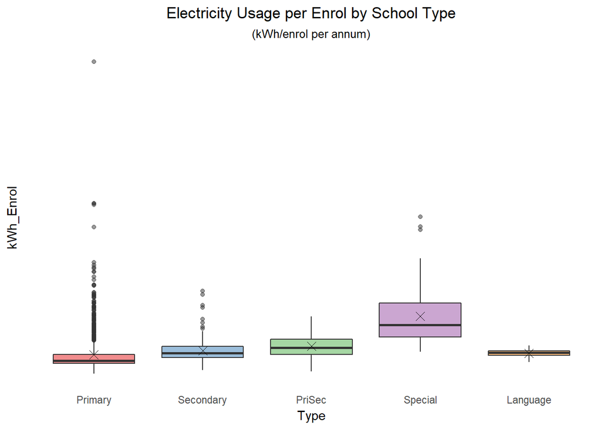

```r
ggplot(data = tbl1617, aes(x = Type, y = kWh_Enrol, fill = Type)) +
  geom_boxplot(alpha = 0.5) +
  stat_summary(fun.y = mean,
               geom = "point",
               shape = 4,
               size = 3) +
  ggtitle("Electricity Usage per Enrol by School Type",
          subtitle = "(kWh/enrol per annum)") +
  scale_fill_brewer(palette = "Set1")+
  theme_minimal() +
  theme(plot.title = element_text(hjust = 0.5),
        plot.subtitle = element_text(hjust = 0.5),
        legend.position = 0)+
  # remove figures if showing plot publicly
  theme(axis.text.y = element_blank(),
        panel.grid = element_blank())
```

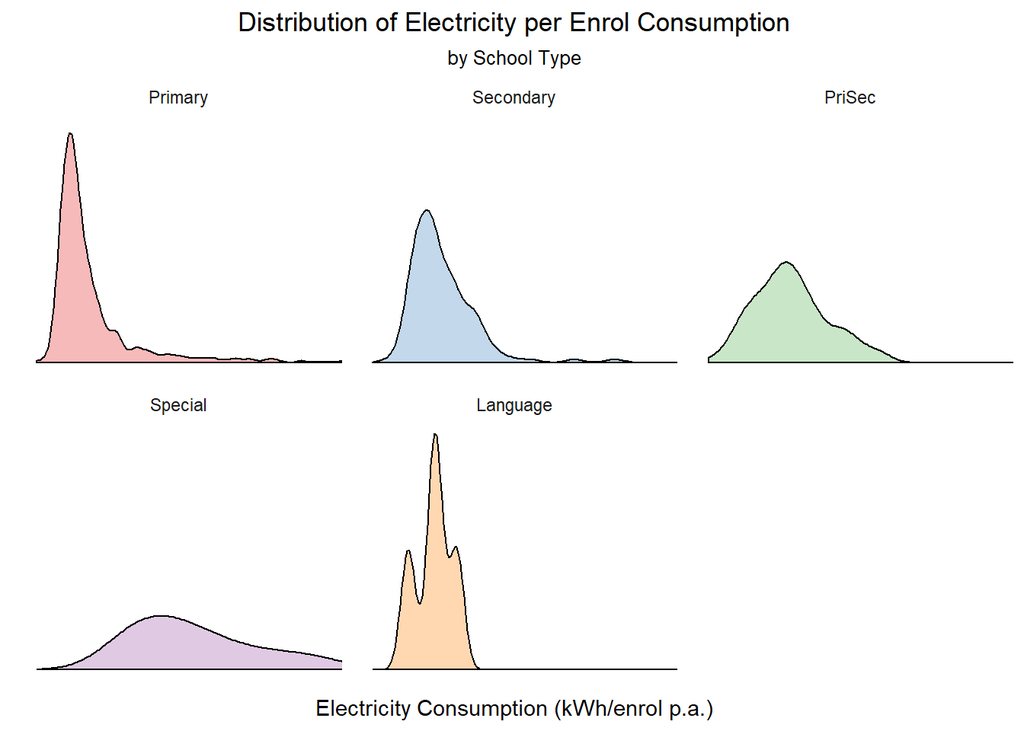

```r
# Density Plot: Electricity consumption per Enrol by School Type
ggplot(data = tbl1617, aes(x = kWh_Enrol, fill = Type)) +
  geom_density(alpha = 0.3) +
  ggtitle("Distribution of Electricity per Enrol Consumption",
          "by School Type") +
  xlab("Electricity Consumption (kWh/enrol p.a.)") +
  facet_wrap(~Type) +
  coord_cartesian(xlim = c(0,2000)) +
  scale_fill_brewer(palette = "Set1") +
  theme_minimal() +
  theme(plot.title = element_text(hjust = 0.5),
        plot.subtitle = element_text(hjust =0.5),
        axis.title.y =  element_blank(),
        legend.position = 0) +
  # remove figures if showing plot publicly
  theme(axis.text = element_blank(),
        panel.grid = element_blank())
```

### Review kWh/enrol Outliers

```r
tbl1617  %>%
  dplyr::select(1,15,3,14,8) %>%
  arrange(desc(kWh_Enrol)) %>%
  arrange(Type) %>%
  group_by(Type) %>%
  top_n(7,kWh_Enrol)

# Bottom 7 kWh/enrol outliers by School Type
tbl1617  %>%
  dplyr::select(1,15,3,14,8) %>%
  arrange(kWh_Enrol) %>%
  arrange(Type) %>%
  group_by(Type) %>%
  top_n(-7,kWh_Enrol)

### Investigate xxxxxxx (xxxxxxx) Schools
tbl1617 %>%
  filter(between(Enrol,10,15)) %>%
  arrange(desc(Elec))

tbl1617 %>%
  filter(between(Area,700,900)) %>%
  arrange(desc(Elec))
```

Extensive inspection of kWh/enrol outliers performed. Involved examination, and where necessary, removal and/or update of observations.

### Remove spurious kWh/enrol observations

```r
remove1 <- -c(6,  235,  587,  589,  892, 1099, 1133, 1212, 1225) # remove these rows
tbl1617 <- tbl1617[remove1,]

# Remove objects no longer needed:
rm(remove,remove1,rcrd.update,rcrd.update1)
```

## Exploratory Data Analysis (Round 2)

### Breakdown of Observations

```r
# Breakdown of Observation by School Type
tbl1617%>%
  tabyl(Type, show_missing_levels = F)%>%
  adorn_totals(where = c("row"))%>%
  adorn_pct_formatting()

# Breakdown by School Type and Solar PV Use

tbl1617%>%
  mutate(Solar = fct_recode(Solar, "NoSolar"="0","Solar"="1"))%>%
  tabyl(Type,Solar, show_missing_levels = F)%>%
  adorn_totals(where = c("row","col"))%>%
  adorn_percentages()%>%
  adorn_pct_formatting()%>%
  adorn_ns(position = "front")
```

### Summary Statistics by Geography

```r
# Summary Electricity Consumption by Geography
by(tbl1617$Elec, tbl1617$Geography, summary)


# Total Electricity by Geography
tbl1617 %>%
  dplyr::select(Elec, Geography) %>%
  group_by(Geography) %>%
  summarise(n =  n(),
            Total = sum(Elec),
            Percent = round(Total/sum(tbl1617$Elec),2))
```

**Comment:** approx. 70% of all electricity usage in this sample is by Urban schools. Since this sample is nearly the whole portfolio, this result can be inferred for the population.

#### Bar Chart: Electricity Consumption by Geography

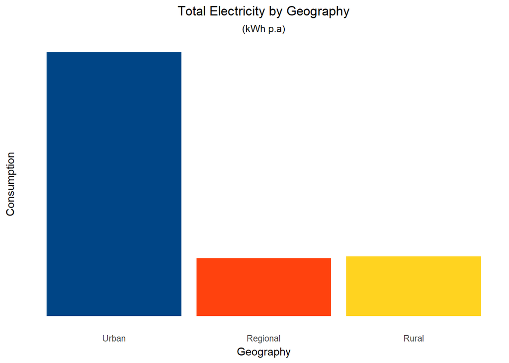

```r
ggplot(tbl1617, aes(x = Geography, y = Elec, fill = Geography)) +
  geom_col() +
  ggtitle("Total Electricity by Geography",
          subtitle = "(kWh p.a)") +
  ylab("Consumption") +
  scale_fill_calc()+
  theme_minimal() +
  theme(legend.position = 0,
        plot.title = element_text(hjust = 0.5),
        plot.subtitle = element_text(hjust = 0.5)) +
  # Hide numbers if showing plot publicly
  theme(axis.text.y = element_blank(),
        panel.grid = element_blank())
```

#### Box Plots: Electricity consumption by Geography

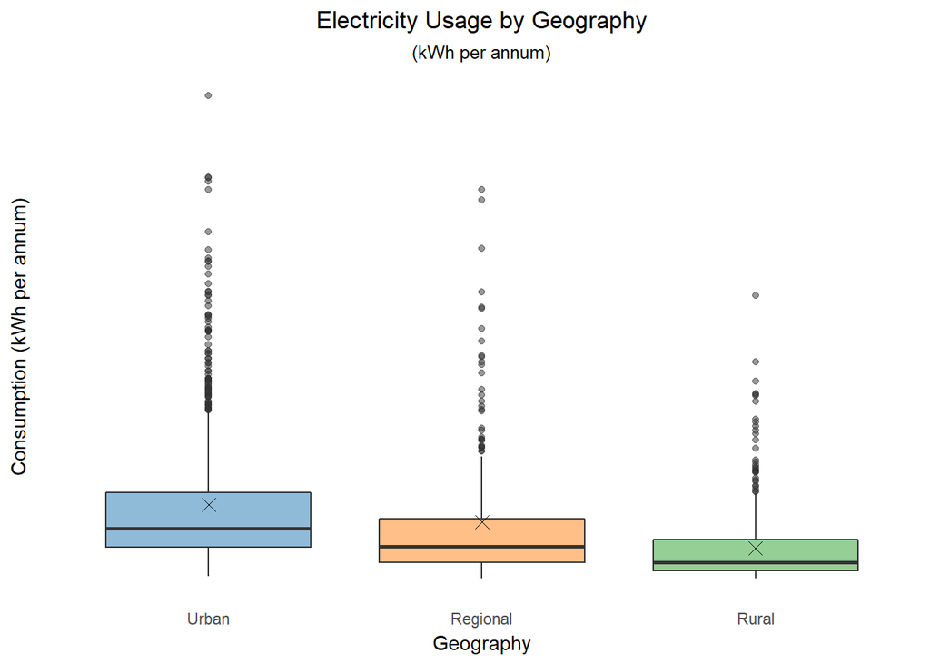

```r
ggplot(data = tbl1617, aes(x = Geography, y = Elec, fill = Geography)) +
  geom_boxplot(alpha = 0.5) +
  stat_summary(fun.y = mean,
               geom = "point",
               shape = 4,
               size = 3) +
  ggtitle("Electricity Usage by Geography",
          subtitle = "(kWh per annum)") +
  ylab("Consumption (kWh per annum)") +
  scale_fill_tableau() +
  theme_minimal() +
  theme(plot.title = element_text(hjust = 0.5),
        plot.subtitle = element_text(hjust = 0.5),
        legend.position = 0) +
  # Hide numbers if showing plot publically
  theme(axis.text.y = element_blank(),
        panel.grid = element_blank())
```

#### Density Plots: Electricity consumption by Geography

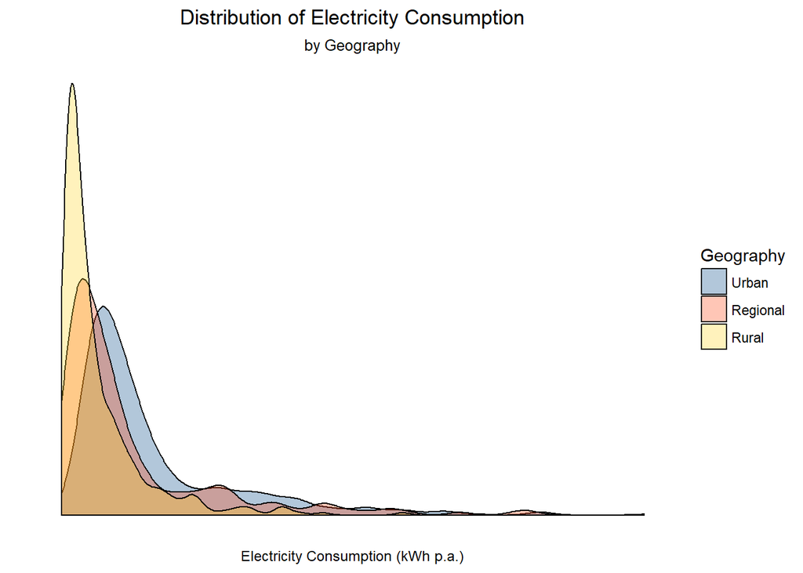

```r
ggplot(data = tbl1617, aes(x = Elec, fill = Geography)) +
  geom_density(alpha = 0.3) +
  ggtitle("Distribution of Electricity Consumption",
          "by Geography") +
  xlab("Electricity Consumption (kWh p.a.)") +
  ylab("")+
  scale_fill_calc() +
  theme_minimal() +
  theme(plot.title = element_text(hjust = 0.5),
        plot.subtitle = element_text(hjust =0.5),
        axis.title = element_text(size = 9))+
  # Hide numbers if showing plot publicly
  theme(axis.text = element_blank(),
        panel.grid = element_blank())
```

### Explore Electricity Use by (Weighted Average) Building Age

```r
# Summary Table
summary(tbl1617$BuildAge)
```

#### Scatter Plot: Electricity Consumption vs Building Age: by Geography

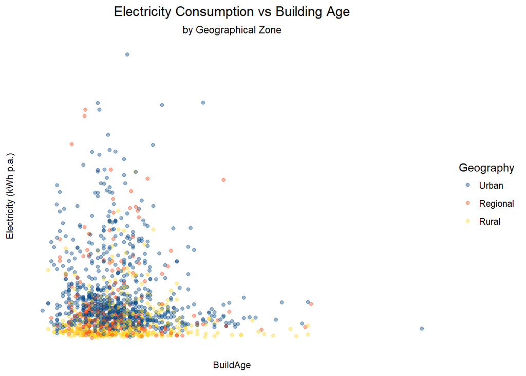

```r
ggplot(tbl1617, aes(x = BuildAge, y = Elec, colour = Geography)) +
  geom_point(alpha = 0.4) +
  ggtitle("Electricity Consumption vs Building Age",
          subtitle = "by Geographical Zone") +
  ylab("Electricity (kWh p.a.)") +
  scale_colour_calc() +
  theme_minimal() +
  theme(plot.title = element_text(hjust = 0.5),
        plot.subtitle = element_text(hjust = 0.5),
        axis.title = element_text(size = 9))+
  # Hide numbers if showing plot publicly
  theme(axis.text = element_blank(),
        panel.grid = element_blank())
```

#### Scatter Plot: Electricity Consumption vs Building Age: by School Type

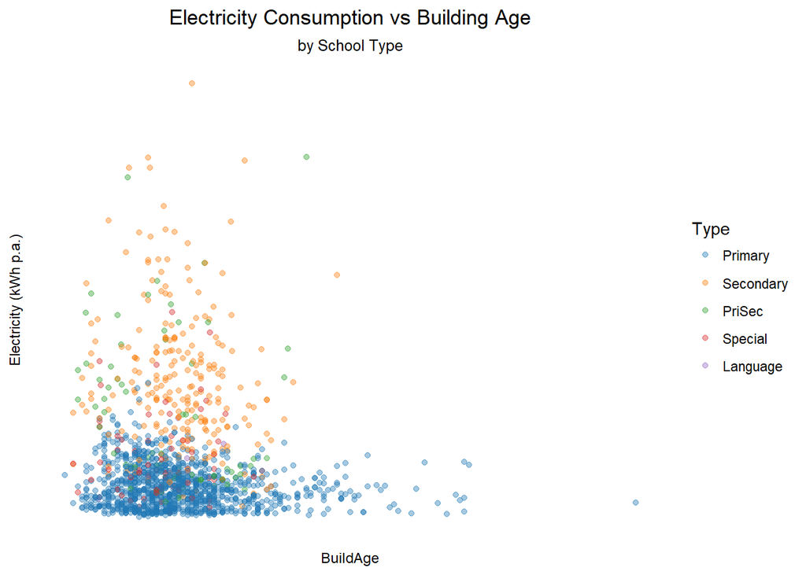

```r
ggplot(tbl1617, aes(x = BuildAge, y = Elec, colour = Type)) +
  geom_point(alpha = 0.4) +
  ggtitle("Electricity Consumption vs Building Age",
          subtitle = "by School Type") +
  ylab("Electricity (kWh p.a.)") +
  scale_color_tableau() +
  theme_minimal() +
  theme(plot.title = element_text(hjust = 0.5),
        plot.subtitle = element_text(hjust = 0.5),
        axis.title = element_text(size = 9))+
  # Hide numbers if showing plot publicly
  theme(axis.text = element_blank(),
        panel.grid = element_blank())
```

#### Electricity vs Discretized Building Age

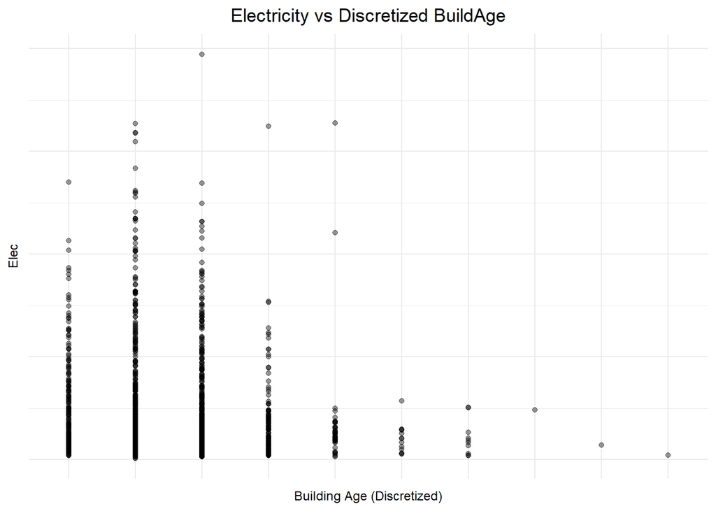

```r
BuildAge_dis <- cut_interval(tbl1617$BuildAge, n = 10)

ggplot(tbl1617, aes(x = BuildAge_dis, y = Elec)) +
  geom_point(alpha = 0.4) +
  ggtitle("Electricity vs Discretized BuildAge") +
  xlab("Building Age (Discretized)") +
  theme_minimal() +
  theme(axis.title = element_text(size = 9),
        plot.title = element_text(hjust=0.5))+
  # Hide numbers if showing plot publicly
  theme(axis.text = element_blank())
```

**Comment:** There does not seem to be a clear relationship between a school’s electricity consumption and the weighted average age of its buildings (i.e. weighted based on construction zones inside buildings). However, building age in this instance is based on *original construction date*, and does not take into account maintenance or other refurbishment works. More research needs to be undertaken with a different measure of schools’ average building age that takes into account more than just original construction dates.

### Exploring Floor Area Distribution

#### Combined Histogram and Boxplot

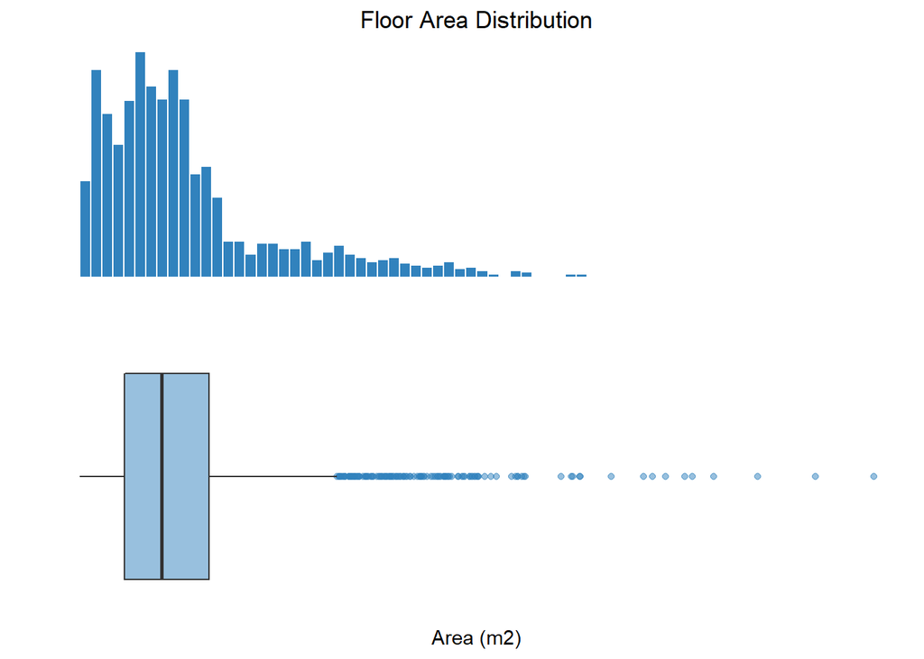

```r
Hist_Area <-  ggplot(tbl1617, aes(x = Area, y = ..density..)) +
  geom_histogram(binwidth = 500, colour = "White", fill = "#3182bd") +
  ggtitle("Floor Area Distribution") +
  ylab("")+
  xlab("")+
  theme_minimal() +
  theme(plot.title = element_text(hjust = 0.5))+
  # Hide numbers if showing plot publicly
  theme(axis.text = element_blank(),
        panel.grid = element_blank())

BP_Area <- ggplot(tbl1617, aes(y = Area, x = "")) +
  geom_boxplot(fill = "#3182bd", outlier.colour = "#3182bd", alpha = 0.5) +
  coord_flip() +
  ylab("Area (m2)")+
  xlab("")+
  theme_minimal()+
  # Hide numbers if showing plot publicly
  theme(axis.text = element_blank(),
        panel.grid = element_blank())

cowplot::plot_grid(Hist_Area, BP_Area, ncol = 1, align = "v") # creates combined plot
```

#### Density Plot: Distribution of Floor Area by School Type

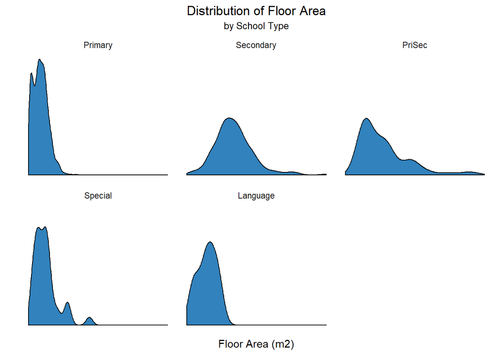

```r
ggplot(tbl1617, aes(x = Area, y = ..density..)) +
  geom_density(fill="#3182bd") +
  labs(title = "Distribution of Floor Area",
       subtitle="by School Type",
       y = "",
       x = "Floor Area (m2)")+
  facet_wrap(~Type) +
  theme_minimal()+
  # Hide numbers if showing plot publicly
  theme(axis.text = element_blank(),
        panel.grid = element_blank(),
        plot.title = element_text(hjust = 0.5),
        plot.subtitle = element_text(hjust = 0.5))
```

#### Boxplot of Area by School Type

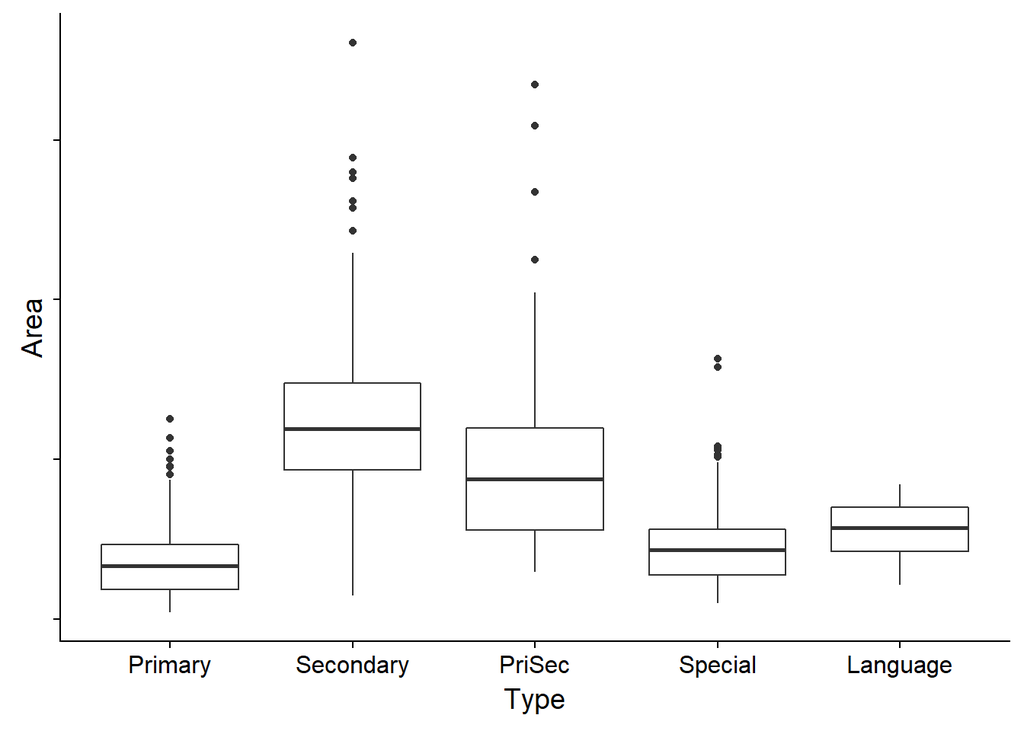

```r
ggplot(tbl1617, aes(y = Area, x = Type)) +
  geom_boxplot()+
  # Hide numbers if showing plot publicly
  theme(axis.text.y = element_blank())
```

### EDA: Correlation Analysis

#### Correlation Matrix

Using the `PerformanceAnalytics::chart.Correlation()` function. The function uses Pearson correlation by default.

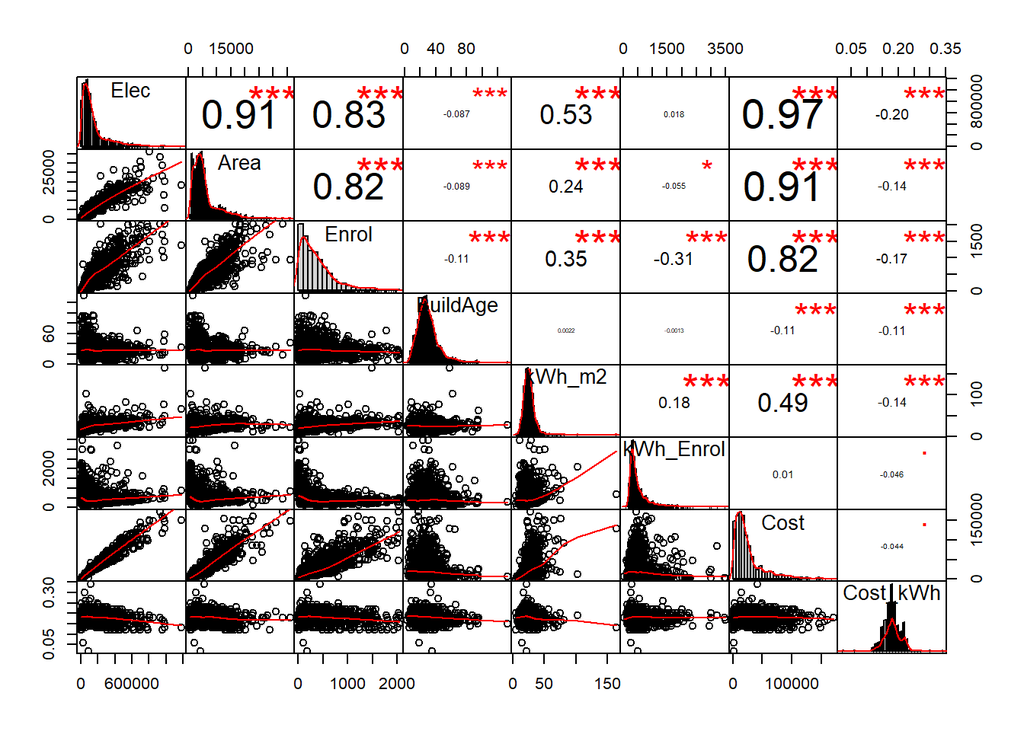

```r
corrmat <- tbl1617[,c("Elec","Area","Enrol","BuildAge","kWh_m2","kWh_Enrol","Cost","Cost_kWh")]
chart.Correlation(corrmat, pch = 19)
```

**Note:** Used the following taxonomy in classifing Pearson correlation:

.00-.19 “very weak” .20-.39 “weak” .40-.59 “moderate” .60-.79 “strong” .80-1.0 “very strong”

*Source:* [Pearson’s Correlation](http://www.statstutor.ac.uk/resources/uploaded/pearsons.pdf)

#### Closer Look at Selected Scatterplot Correlations

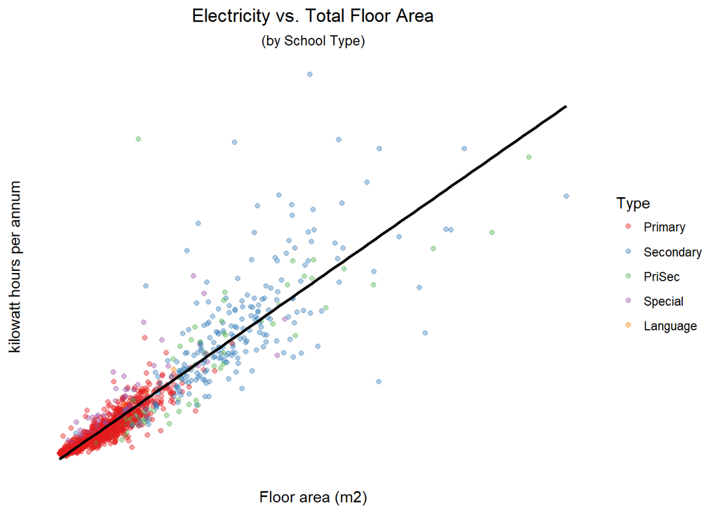

```r
## Electricity vs. Floor Area (by School Type)
ggplot(tbl1617, aes(y = Elec, x = Area, colour = Type)) +
  geom_point(alpha = 0.4) +
  geom_smooth(method = "lm", se = FALSE, colour = "black") +
  ggtitle("Electricity vs. Total Floor Area", subtitle = "(by School Type)") +
  xlab("Floor area (m2)") +
  ylab("kilowatt hours per annum") +
  scale_color_brewer(palette = "Set1") +
  theme_minimal() +
  theme(plot.title = element_text(hjust = 0.5),
        plot.subtitle = element_text(hjust = .5))+
  # Hide numbers if showing plot publicly
  theme(axis.text = element_blank(),
        panel.grid = element_blank())
```

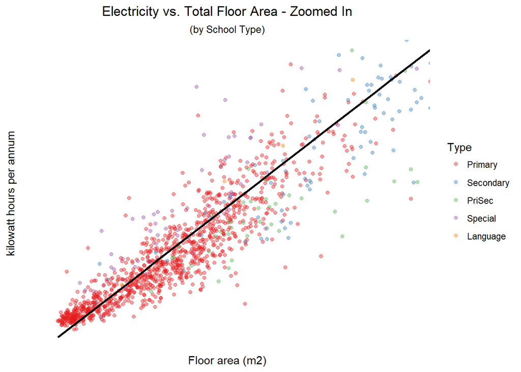

```r
# Electricity vs. Floor Area (by school type) - Zoomed In
ggplot(tbl1617, aes(y = Elec, x = Area, colour = Type)) +
  geom_point(alpha = 0.4) +
  geom_smooth(method = "lm", se = FALSE, colour = "black") +
#  geom_smooth(method = "lm", se = FALSE) +
  coord_cartesian(xlim = c(0,10000), ylim=c(0,300000)) +
  ggtitle("Electricity vs. Total Floor Area - Zoomed In",
          subtitle = "(by School Type)") +
  xlab("Floor area (m2)") +
  ylab("kilowatt hours per annum") +
  scale_color_brewer(palette = "Set1") +
  theme_minimal() +
  theme(plot.title = element_text(hjust = 0.5),
        plot.subtitle = element_text(hjust = .5))+
  # Hide numbers if showing plot publicly
  theme(axis.text = element_blank(),
        panel.grid = element_blank())
```

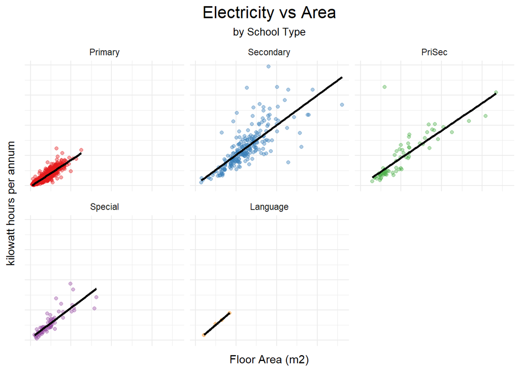

```r
# Electricity vs. Floor Area (by school type) - Facetted
ggplot(tbl1617, aes(y = Elec, x = Area, colour = Type)) +
  geom_point(alpha = 0.4) +
  geom_smooth(method = "lm", se = FALSE, colour = "black") +
  facet_wrap(~Type) +
  ggtitle("Electricity vs Area", subtitle = "by School Type") +
  xlab("Floor Area (m2)") +
  ylab ("kilowatt hours per annum")+
  scale_color_brewer(palette = "Set1") +
  theme_minimal() +
  theme(plot.title = element_text(size = 16, hjust= 0.5),
        plot.subtitle = element_text(size = 10, hjust = 0.5),
        legend.position = "none")+
  # Hide numbers if showing plot publicly
  theme(axis.text = element_blank())
```

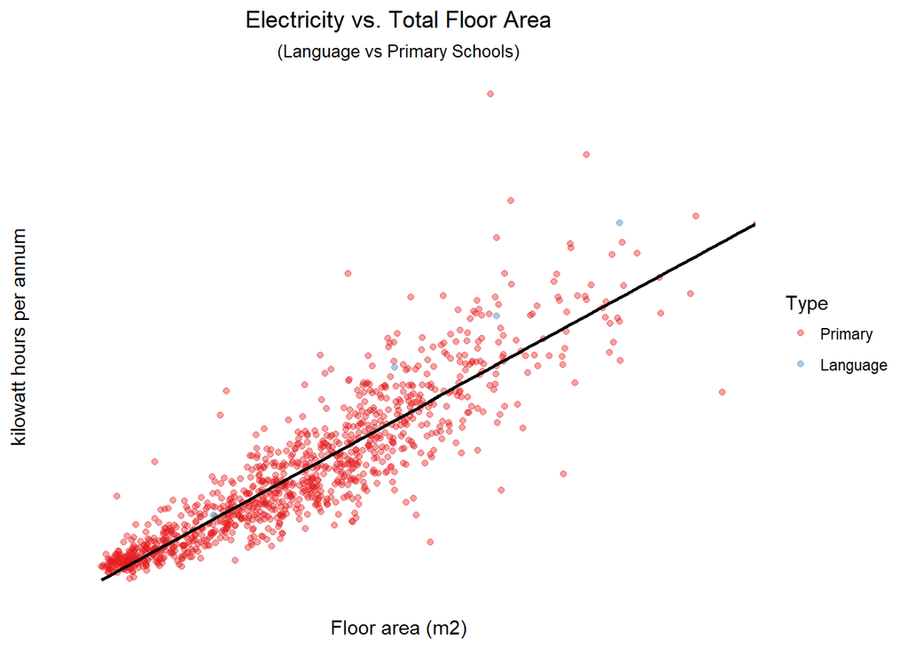

```r
# Electricity vs. Floor Area - Language vs Primary Schools
ggplot(subset(tbl1617, Type %in% c("Language", "Primary")), aes(y = Elec, x = Area, colour = Type)) +
  geom_point(alpha = 0.4) +
  geom_smooth(method = "lm", se = FALSE, colour = "black") +
  coord_cartesian(xlim = c(0,10000) ) +
  ggtitle("Electricity vs. Total Floor Area",
          subtitle = "(Language vs Primary Schools)") +
  xlab("Floor area (m2)") +
  ylab("kilowatt hours per annum") +
  scale_color_brewer(palette = "Set1") +
  theme_minimal() +
  theme(plot.title = element_text(hjust = 0.5),
        plot.subtitle = element_text(hjust = .5))+
  # Hide numbers if showing plot publicly
  theme(axis.text = element_blank(),
        panel.grid = element_blank())
```

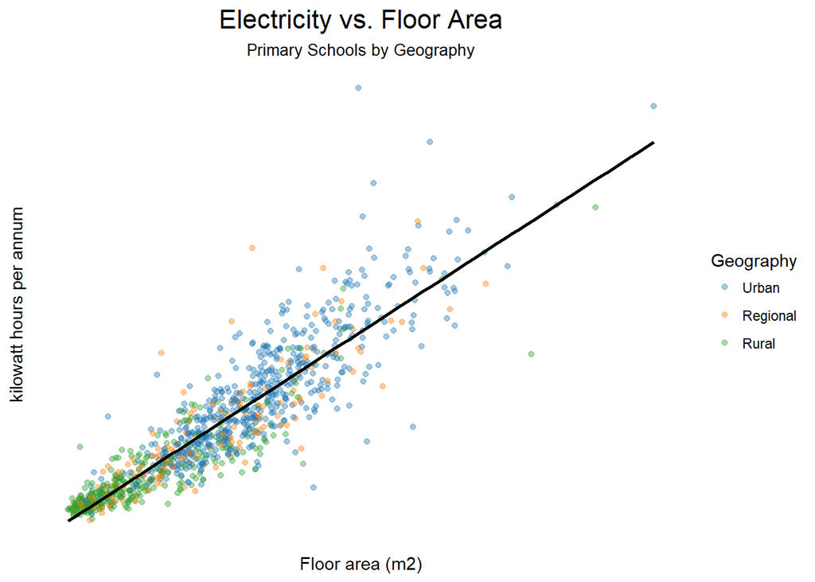

```r
# Electricity vs. Floor Area - Primary Schools by Geography
ggplot(data = tbl1617[tbl1617$Type=="Primary",],
       aes(y=Elec, x = Area, colour = Geography)) +
  geom_point(alpha = 0.4) +
  geom_smooth(method = "lm", se = FALSE, colour = "black") +
  ggtitle("Electricity vs. Floor Area", subtitle = "Primary Schools by Geography")+
  xlab("Floor area (m2)") +
  ylab("kilowatt hours per annum") +
  scale_color_tableau() +
  theme_minimal() +
  theme(plot.title = element_text(size = 16, hjust =0.5),
        plot.subtitle = element_text(size = 10, hjust = 0.5))+
  # Hide numbers if showing plot publicly
  theme(axis.text = element_blank(),
        panel.grid = element_blank())
```